# Investigating COVID-19 Virus Trends

# Introduction

The COVID-19 pandemic has significantly impacted global health systems and economies, leading to extensive data collection efforts to better understand the spread and effects of the virus. This project utilizes real-world data collected between January 20 and June 1, 2020, to analyze trends in COVID-19 cases and testing across different countries.

The main objective of this project is to determine which countries have reported the highest number of positive cases in relation to the number of tests conducted. By using R and the dplyr package, we will clean, manipulate, and analyze the dataset to extract meaningful insights. This hands-on approach will enhance our data analysis skills while demonstrating the importance of data-driven decision-making in public health.

# Understanding the Data

1. Download the `covid19.csv` CSV file.
2. Load this file using the function `read_csv()` from the `readr` package.

```r
# Load library
library(readr)

# Load CSV file
covid_df <- read_csv("covid19.csv", show_col_types = FALSE)

# View Data frame
covid_df
```

| Date | Continent_Name | Two_Letter_Country_Code | Country_Region | Province_State | positive | hospitalized | recovered | death | total_tested | active | hospitalizedCurr | daily_tested | daily_positive |
| --- | --- | --- | --- | --- | --- | --- | --- | --- | --- | --- | --- | --- | --- |
| 2020-01-20 | Asia | KR | South Korea | All States | 1 | 0 | 0 | 0 | 4 | 0 | 0 | 0 | 0 |
| 2020-01-22 | North America | US | United States | All States | 1 | 0 | 0 | 0 | 1 | 0 | 0 | 0 | 0 |
| 2020-01-22 | North America | US | United States | Washington | 1 | 0 | 0 | 0 | 1 | 0 | 0 | 0 | 0 |
| 2020-01-23 | North America | US | United States | All States | 1 | 0 | 0 | 0 | 1 | 0 | 0 | 0 | 0 |
| 2020-01-23 | North America | US | United States | Washington | 1 | 0 | 0 | 0 | 1 | 0 | 0 | 0 | 0 |
| 2020-01-24 | Asia | KR | South Korea | All States | 2 | 0 | 0 | 0 | 27 | 0 | 0 | 5 | 0 |
| 2020-01-24 | North America | US | United States | All States | 1 | 0 | 0 | 0 | 1 | 0 | 0 | 0 | 0 |
| 2020-01-24 | North America | US | United States | Washington | 1 | 0 | 0 | 0 | 1 | 0 | 0 | 0 | 0 |
| 2020-01-25 | Oceania | AU | Australia | All States | 4 | 0 | 0 | 0 | 0 | 0 | 0 | 0 | 0 |
| 2020-01-25 | Oceania | AU | Australia | Australian Capital Territory | 0 | 0 | 0 | 0 | 0 | 0 | 0 | 0 | 0 |

[output cut: 990 more lines]

3. Determine the dimension of the dataframe, `covid_df` by using the function `dim()`.

```r
# Set Variable as Dimensions of Data frame
dims <- dim(covid_df)

# View Variable
dims
```

```
[1] 10903    14
```

4. Determine the column names of `covid_df` using the `colnames()` function.

```r
# Set Variable as Names of Columns
vector_cols <- colnames(covid_df)

# View Variable
vector_cols
```

```
 [1] "Date"                    "Continent_Name"          "Two_Letter_Country_Code"
 [4] "Country_Region"          "Province_State"          "positive"
 [7] "hospitalized"            "recovered"               "death"
[10] "total_tested"            "active"                  "hospitalizedCurr"
[13] "daily_tested"            "daily_positive"
```

5. Display the first few rows of the `covid_df` dataset using the function `head()`.

```r
# View First 6 Rows of Data frame
head(covid_df)
```

| Date | Continent_Name | Two_Letter_Country_Code | Country_Region | Province_State | positive | hospitalized | recovered | death | total_tested | active | hospitalizedCurr | daily_tested | daily_positive |
| --- | --- | --- | --- | --- | --- | --- | --- | --- | --- | --- | --- | --- | --- |
| 2020-01-20 | Asia | KR | South Korea | All States | 1 | 0 | 0 | 0 | 4 | 0 | 0 | 0 | 0 |
| 2020-01-22 | North America | US | United States | All States | 1 | 0 | 0 | 0 | 1 | 0 | 0 | 0 | 0 |
| 2020-01-22 | North America | US | United States | Washington | 1 | 0 | 0 | 0 | 1 | 0 | 0 | 0 | 0 |
| 2020-01-23 | North America | US | United States | All States | 1 | 0 | 0 | 0 | 1 | 0 | 0 | 0 | 0 |
| 2020-01-23 | North America | US | United States | Washington | 1 | 0 | 0 | 0 | 1 | 0 | 0 | 0 | 0 |
| 2020-01-24 | Asia | KR | South Korea | All States | 2 | 0 | 0 | 0 | 27 | 0 | 0 | 5 | 0 |

6. Display the summary of the `covid_df` dataset using the function `glimpse()` from the `tibble` package.

```r
# Load library
library(tibble)

# Show Summary of Data frame
glimpse <- glimpse(covid_df)
```

```
Rows: 10,903
Columns: 14
$ Date                    <date> 2020-01-20, 2020-01-22, 2020-01-22, 2020-01-23, 2020-01-23, 2020-01…
$ Continent_Name          <chr> "Asia", "North America", "North America", "North America", "North Am…
$ Two_Letter_Country_Code <chr> "KR", "US", "US", "US", "US", "KR", "US", "US", "AU", "AU", "AU", "A…
$ Country_Region          <chr> "South Korea", "United States", "United States", "United States", "U…
$ Province_State          <chr> "All States", "All States", "Washington", "All States", "Washington"…
$ positive                <dbl> 1, 1, 1, 1, 1, 2, 1, 1, 4, 0, 3, 0, 0, 0, 0, 1, 0, 1, 1, 1, 4, 0, 3,…
$ hospitalized            <dbl> 0, 0, 0, 0, 0, 0, 0, 0, 0, 0, 0, 0, 0, 0, 0, 0, 0, 0, 0, 0, 0, 0, 0,…
$ recovered               <dbl> 0, 0, 0, 0, 0, 0, 0, 0, 0, 0, 0, 0, 0, 0, 0, 0, 0, 0, 0, 0, 0, 0, 0,…
$ death                   <dbl> 0, 0, 0, 0, 0, 0, 0, 0, 0, 0, 0, 0, 0, 0, 0, 0, 0, 0, 0, 0, 0, 0, 0,…
$ total_tested            <dbl> 4, 1, 1, 1, 1, 27, 1, 1, 0, 0, 0, 0, 0, 0, 0, 0, 0, 31, 1, 1, 0, 0, …
$ active                  <dbl> 0, 0, 0, 0, 0, 0, 0, 0, 0, 0, 0, 0, 0, 0, 0, 0, 0, 0, 0, 0, 0, 0, 0,…
$ hospitalizedCurr        <dbl> 0, 0, 0, 0, 0, 0, 0, 0, 0, 0, 0, 0, 0, 0, 0, 0, 0, 0, 0, 0, 0, 0, 0,…
$ daily_tested            <dbl> 0, 0, 0, 0, 0, 5, 0, 0, 0, 0, 0, 0, 0, 0, 0, 0, 0, 0, 0, 0, 0, 0, 0,…
$ daily_positive          <dbl> 0, 0, 0, 0, 0, 0, 0, 0, 0, 0, 0, 0, 0, 0, 0, 0, 0, 0, 0, 0, 0, 0, 0,…
```

# Isolating the Rows We Need

1. Filter the rows related to `"All States"` from the `Province_State` column and remove the `Province_State` column from `covid_df` dataframe.

```r
# Load Library
library(dplyr)

# Filter Data frame to have only "All States", then Remove Column
covid_df_all_states <- covid_df %>%
  filter(Province_State == "All States") %>%
  select(-Province_State)

# View New Data frame
head(covid_df_all_states)
```

| Date | Continent_Name | Two_Letter_Country_Code | Country_Region | positive | hospitalized | recovered | death | total_tested | active | hospitalizedCurr | daily_tested | daily_positive |
| --- | --- | --- | --- | --- | --- | --- | --- | --- | --- | --- | --- | --- |
| 2020-01-20 | Asia | KR | South Korea | 1 | 0 | 0 | 0 | 4 | 0 | 0 | 0 | 0 |
| 2020-01-22 | North America | US | United States | 1 | 0 | 0 | 0 | 1 | 0 | 0 | 0 | 0 |
| 2020-01-23 | North America | US | United States | 1 | 0 | 0 | 0 | 1 | 0 | 0 | 0 | 0 |
| 2020-01-24 | Asia | KR | South Korea | 2 | 0 | 0 | 0 | 27 | 0 | 0 | 5 | 0 |
| 2020-01-24 | North America | US | United States | 1 | 0 | 0 | 0 | 1 | 0 | 0 | 0 | 0 |
| 2020-01-25 | Oceania | AU | Australia | 4 | 0 | 0 | 0 | 0 | 0 | 0 | 0 | 0 |

# Isolating the Columns We Need

1. Select the following column, related to the daily measures, from the `covid_df_all_states`: `Date`, `Country_Region`, `active`, `hospitalizedCurr`, `daily_tested`, `daily_positive`.

```r
# Set Vector to have Desired Columns
columns_to_save <- c("Date", "Country_Region", "active", "hospitalizedCurr", "daily_tested", "daily_positive")

# Remove Cumulative Data, only Daily
covid_df_all_states_daily <- covid_df_all_states %>%
  select(all_of(columns_to_save))

# View New Data frame
head(covid_df_all_states_daily)
```

| Date | Country_Region | active | hospitalizedCurr | daily_tested | daily_positive |
| --- | --- | --- | --- | --- | --- |
| 2020-01-20 | South Korea | 0 | 0 | 0 | 0 |
| 2020-01-22 | United States | 0 | 0 | 0 | 0 |
| 2020-01-23 | United States | 0 | 0 | 0 | 0 |
| 2020-01-24 | South Korea | 0 | 0 | 5 | 0 |
| 2020-01-24 | United States | 0 | 0 | 0 | 0 |
| 2020-01-25 | Australia | 0 | 0 | 0 | 0 |

# Extracting the Top Ten Countries with Most Covid-19 Cases

1. Write code to summarize the `covid_df_all_states_daily` dataframe by computing the sum of the number of tested, positive, active and hospitalized cases grouped by the `Country_Region` column.

```r
# Group Data fram by Country and Sum each Column
covid_df_all_states_daily_sum <- covid_df_all_states_daily %>%
  group_by(Country_Region) %>%
  summarise(tested = sum(daily_tested), positive = sum(daily_positive), active = sum(active), hospitalized = sum(hospitalizedCurr)) %>%
  arrange(desc(tested))

# View New Data frame
covid_df_all_states_daily_sum
```

| Country_Region | tested | positive | active | hospitalized |
| --- | --- | --- | --- | --- |
| United States | 17282363 | 1877179 | 0 | 0 |
| Russia | 10542266 | 406368 | 6924890 | 0 |
| Italy | 4091291 | 251710 | 6202214 | 1699003 |
| India | 3692851 | 60959 | 0 | 0 |
| Turkey | 2031192 | 163941 | 2980960 | 0 |
| Canada | 1654779 | 90873 | 56454 | 0 |
| United Kingdom | 1473672 | 166909 | 0 | 0 |
| Australia | 1252900 | 7200 | 134586 | 6655 |
| Peru | 976790 | 59497 | 0 | 0 |
| Poland | 928256 | 23987 | 538203 | 0 |

[output cut: 98 more lines]

2. Extract the top ten rows from the `covid_df_all_states_daily_sum` dataframe using the command `head(covid_df_all_states_daily_sum, 10)`.

```r
# Safe only Top 10 Countries from Data frame
covid_top_10 <- head(covid_df_all_states_daily_sum, 10)

# View New Data frame
covid_top_10
```

| Country_Region | tested | positive | active | hospitalized |
| --- | --- | --- | --- | --- |
| United States | 17282363 | 1877179 | 0 | 0 |
| Russia | 10542266 | 406368 | 6924890 | 0 |
| Italy | 4091291 | 251710 | 6202214 | 1699003 |
| India | 3692851 | 60959 | 0 | 0 |
| Turkey | 2031192 | 163941 | 2980960 | 0 |
| Canada | 1654779 | 90873 | 56454 | 0 |
| United Kingdom | 1473672 | 166909 | 0 | 0 |
| Australia | 1252900 | 7200 | 134586 | 6655 |
| Peru | 976790 | 59497 | 0 | 0 |
| Poland | 928256 | 23987 | 538203 | 0 |

# Identifying the Highest Positive Against Tested Cases

1. Create the vectors from the covid_top_10 dataframe.

```r
# Save each Column as Vector
countries <- covid_top_10$Country_Region
tested_cases <- covid_top_10$tested
positive_cases <- covid_top_10$positive
active_cases <- covid_top_10$active
hospitalized_cases <- covid_top_10$hospitalized
```

2. Write code to name the previous vectors: `tested_cases`, `positive_cases`, `active_cases`, and `hospitalized_cases` with the country names’ vector `countries` using the function `names()`.

```r
names(tested_cases) <- countries
names(positive_cases) <- countries
names(active_cases) <- countries
names(hospitalized_cases) <- countries
```

3. Identify the top three positive against tested cases.

```r
# Identify Ratios  for each Country
positive_cases / tested_cases
```

```
 United States         Russia          Italy          India         Turkey         Canada
   0.108618191    0.038546552    0.061523368    0.016507300    0.080711720    0.054915490
United Kingdom      Australia           Peru         Poland
   0.113260617    0.005746668    0.060910738    0.025840932
```

```r
# Store Top 3 Ratios
positive_tested_top_3 <- c("United Kingdom" = 0.113260617, "United States" = 0.108618191, "Turkey" = 0.080711720)

# View Top 3 Ratios with Country
positive_tested_top_3
```

```
United Kingdom  United States         Turkey
    0.11326062     0.10861819     0.08071172
```

# Keeping Relevant Information

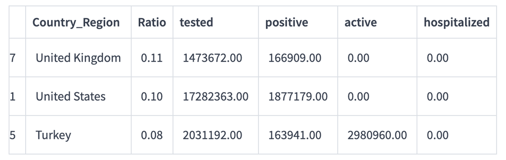

1. Create the following vectors from the table above.

```r
# Create Vectors
united_kingdom <- c(0.11, 1473672, 166909, 0, 0)
united_states <- c(0.10, 17282363, 1877179, 0, 0)
turkey <- c(0.08, 2031192, 163941, 2980960, 0)
```

2. Create a matrix combining the vectors: `united_kingdom`, `united_states`, and `turkey`.

```r
# Create Matrix
covid_mat <- rbind(united_kingdom, united_states, turkey)

# Rename
colnames(covid_mat) <- c("Ratio", "tested", "positive", "active", "hospitalized")

# View Matrix
covid_mat
```

```
               Ratio   tested positive  active hospitalized
united_kingdom  0.11  1473672   166909       0            0
united_states   0.10 17282363  1877179       0            0
turkey          0.08  2031192   163941 2980960            0
```

# Putting All Together

1. Create a character variable named `question` that contains our question.

```r
# Set Question
question <- "Which countries have had the highest number of positive cases against the number of tests?"
```

2. Create a named vector that contains our answer with the following command:

```r
# Set Answer
answer <- c("Positive tested cases" = positive_tested_top_3)
```

3. Create a list that contains the data structures mentioned above.

```r
# Store each Datastructures in List
dataframes_list <- list(covid_df, covid_df_all_states, covid_df_all_states_daily, covid_top_10)
matrices_list <- list(covid_mat)
vectors_list <- list(vector_cols, countries)

# Store Previous Lists with Names
data_structure_list <- list(
  dataframes = dataframes_list,
  matrices = matrices_list,
  vectors = vectors_list
)
```

4. Create a list that contains the following lists: `question`, `answer`, and `data_structure_list`.

```r
# Store Everything
covid_analysis_list <- list(question, answer, data_structure_list)

# View Second List
covid_analysis_list[[2]]
```

```
Positive tested cases.United Kingdom  Positive tested cases.United States
                          0.11326062                           0.10861819
        Positive tested cases.Turkey
                          0.08071172
```